# Introduction to reproducible analyses and documents with R Markdown

Feb 22, 2021

## Learning Goals

- understand the capabilities and disadvantages of R Markdown documents
- learn the structure and syntax of R Markdown documents
- produce and customize the appearance of R output
- compile your R Markdown documents into PDFs, HTML documents, and slide presentations

## You should have:

- installation of R
- installation of R Studio
- installation of the `tidyverse` suite of R packages
- installation of the `tinytex` R package
- some familiarity with R would help, but isn’t strictly necessary

## A little bit about myself

Hi! My name’s Michael (he/him), I’m a PhD student in the Dept. of Statistical Sciences.

I use R (and R Markdown) nearly every day for my research in demographic estimation.

Feel free to interrupt with questions!

## What is R Markdown?

## What is R Markdown?

R Markdown is a **document format** that lets you mix text and R code and output.

From an R Markdown file (`.Rmd`), you can create PDFs, webpages, slide presentations, etc.

## Example uses

In my own work:

- keeping research notes
- completing assignments
- writing papers

Other uses:

- personal websites (via `blogdown` package)
- creating interactive tutorials (via `learnr` package)
- entire books
- websites

## ok, but why?

1. Keep code, figures, and text in one place (no more copy and pasting)
2. Lends well to *meaningful* reproducibility
3. Versatile – variety of outputs, and you don’t even need to use R!

## It can’t be all good…

1. Custom formatting is more difficult
2. Learning curve is steeper than word processors
3. Need R + R Studio to edit (which collaborators may not have)

## Check out this lecture!

https://www.youtube.com/watch?v=Hl798H6J-bg&feature=youtu.be

Also the Toronto Data Workshop!

https://rohanalexander.com/toronto_data_workshop.html

## Using R Markdown

## A brief note on getting oriented in R Studio

Editor (default top left panel) - where you edit scripts, files Console (bottom left panel) - an active session of R Top right panel - workflow helpers (e.g. objects in environment, Git) Bottom right panel - viewer, and help panel

## Getting set up

1. Open R Studio

(1.5. Set working directory (Session -> Set Working Directory))

1. File -> New -> R Markdown… (accept defaults)
2. A new tab should open in your editor

That’s it! This is an R Markdown file!

“Knit” the file using the **Knit** button near the top.

## Components of an R Markdown file

## A couple key components:

1. header
2. text
3. code “chunks”

## The header

The header contains metadata about the document:

- `title`, `author`, `date` (as character strings)
- `output`: the desired format – most common would be `pdf_document` or `html_document`

## Text

“Markdown” is actually a specific text format (used outside of this context).

The key idea is that it’s similar to plain text, and formatting is simple. We’ll come back to this later.

## Code chunks

Code chunks contain R code, and are written like this:

````
```{r}
1 + 1
```
````

```
2
```

These code chunks are evaluated when you knit the Rmd, and the result appears in the output.

## Code chunks

Actually, code chunks don’t need to be R code! You can replace `r` with `python` to evaluate Python code, or use other engines (I don’t have experience here)

````
```{python}
1 + 1
```
````

## Checkpoint 1

1. R Markdown is a way to versatile, reproducible way to write documents (and more).
2. “Knitting” your first R Markdown file
3. R Markdown documents consist of a metadata header, text, and code chunks.

## Questions?

## Making text richer

We want more from our text editors/word processors. In particular, things like: section headers, bolding, italics, links, equations

## Headers

Headers are preceded by `#`

```
# big title

## small title

### even smaller title

some text
```

## Text formatting

- bolding: `**some bold text**`
- italics: `*some italic text*`
- links: `[link text](https://www.utoronto.ca/)`
- equations (inline:) `$y = mx + b$`

## Text formatting

- **bold text**
- *italic text*
- [link text](https://www.utoronto.ca/)
- \(y = mx + b\)

## Citations

- need a BibTeX `.bib` file
- put the path to the bib file in header `bibliography: my_references.bib`
- add “References” as a section at the end of your document

You can find BibTeX entries using Google Scholar, or citation managers usually have a way to export.

## Citations

Then:

- `@bibentry2021` for in-text reference
- `[@bibentry2021]` for usual citation

`@xie2018r says R Markdown is great.` makes:

Xie, Allaire, and Grolemund (2018) says R Markdown is great

`R Markdown is great [@xie2018r].` makes:

R Markdown is great (Xie, Allaire, and Grolemund 2018).

## Quick exercise

1. Find a journal article on the last vegetable you ate
2. Write a quick sentence, and add a citation

(reminder: get bib entry, update header, put in-line citation)

## Graphics and tables

- images, R plots, tables

## To include an image

`![my image caption](path/to/image.jpg){width = 50%}`

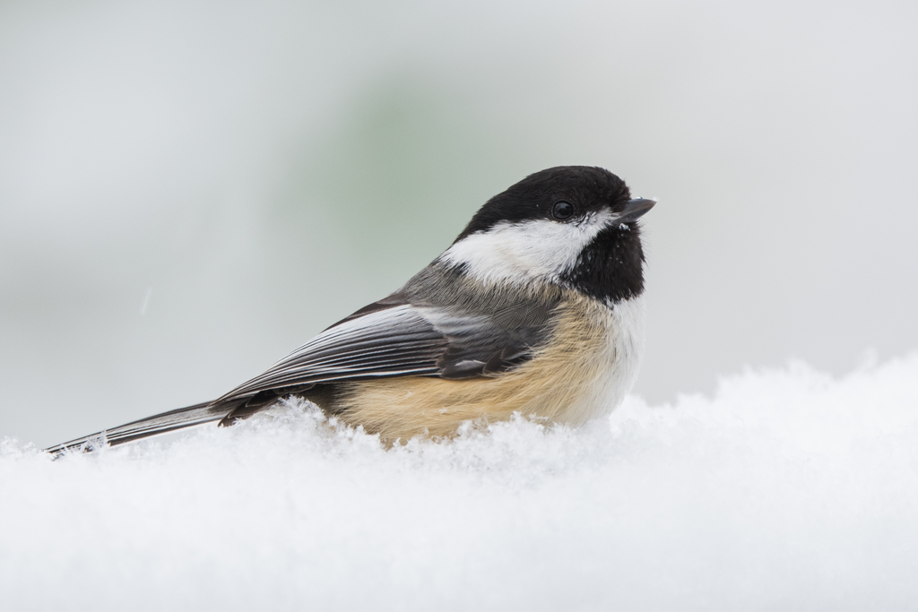

A bird.

Picture from: https://unsplash.com/photos/rpig3nMmtt4

## Plots (and other R output)

R output will show up automatically.

Can adjust behaviour via “chunk options”: e.g. whether to evaluate the code, whether to show the code, whether to hide output

## Chunk options

Set the option globally for the document in the first chunk:

`knitr::opts_chunk$set(echo = FALSE)`

For a specific chunk:

````
```{r, echo = FALSE}
1 + 1
```
````

## Chunk options

- `echo = TRUE` (default): print the code in the final document
- `eval = TRUE` (default): evaluate the chunk
- `include = TRUE` (default): evaluate the chunk and show code and output (if `FALSE`, hide code and output)
- `results = 'markup'`: show (formatted) results (if `'hide'`)
- `warning = TRUE`(default): print warning messages

## Chunk options

e.g. If I want to show code, but not evaluate the result:

````
```{r, echo = TRUE, eval = FALSE}
1 + 1
```
````

## Quick exercise

In a test document:

1. invisibly assign a numeric value to a variable `x` (e.g. `x <- 3`)
2. return the number divided by \(\pi\) (`pi`), showing the code and result

(Keep this document open! We’ll use it again in a little bit)

## Tables

Data tables in R are usually dataframes.

```r
data.frame(x = 1:2, y = 3:4)
```

```
##   x y
## 1 1 3
## 2 2 4
```

To make a table look nicer, use `knitr::kable()`

| x | y |
| --- | --- |
| 1 | 3 |
| 2 | 4 |

## Checkpoint 2

1. Formatting text (headers, bold etc.)
2. Customizing code chunks with chunk options
3. Making tables nice with `kable()`

Questions?

## Some more stuff

## Change the document type

- `output: pdf_document`
- `output: html_document`
- `output: word_document` (iffy)
- `output: beamer_presentation`
- `output: ioslides_presentation`

More info here: https://rmarkdown.rstudio.com/formats.html

## Lists

`*` makes a list like

- this

```
* multi-level...
  * lists
```

- multi-level…
  - lists

## Include a table of contents

```
output:
  pdf_document:
    toc: true
```

adjust with `toc_depth:` option

## Evaluate code in-line

Write “20 + pi is approximately `` `r 20+pi` ``”

Appears as: “20 + pi is approximately 23.1415927.”

## Evaluate code in-line (use case)

Create *dynamic* text that depends on the analysis in your code.

There have been `` `r n_vaccinations` `` vaccine doses administered in Ontario, which corresponds to `` `r n_vaccinations/population` `` doses per capita, or `` `r n_vaccinations/population * 100000` `` per 100k people.

## Customizing figure output

Figure captions with `fig.cap=` code chunk option

Figure size with `fig.width=` and `fig.height=` code chunk options (default unit is inches)

## Workflow tips/quirks

- handling directories

R Markdown always runs from the directory *of the .Rmd file* – not the working directory.

For big projects, I’d recommend the `here` package, so that directories point to the “base” project directory

## Workflow tips/quirks

- collapsing and running code chunks (demo)
- R Markdown runs code in a new environment (demo)

## Presentations in R Markdown

This (simple) presentation was made in R Markdown! Presentations can get really fancy.

The basic building block is `##` to make a new slide. (demo)

Look into the `xaringan` R package for fancy options (https://github.com/yihui/xaringan)

## Questions?

## Beyond the basics

## Programatic generation of reports

Generate (possibly many) reports from a script

In header:

```
params:
  param_name1: param1_value
  param_name2: param2_value
```

In R:

`rmarkdown::render("path/to/file.Rmd", params = ...)`

## Programmatic generation of reports

Possible use cases

1. A report is automatically generated at the end of a script
2. Repeat the same analysis for multiple similar datasets

## Maps

In HTML, you can include (interactive) maps using `leaflet`, and other R mapping packages.

```r
library(leaflet)

leaflet() %>% addTiles() %>%
  addPopups(-79.39967927305904, 43.66457135213694, "Robarts Library")
```

[interactive chart not shown]

## Where to look for help

Hard to cover everything you’d need! Help is abundant on the Internet

- [R Markdown Cheat Sheet](https://rstudio.com/wp-content/uploads/2015/02/rmarkdown-cheatsheet.pdf)
- [R Markdown Cookbook](https://bookdown.org/yihui/rmarkdown-cookbook/)
- [The Definitive Guide to R Markdown](https://bookdown.org/yihui/rmarkdown/)

## Try it for yourself!

The Perseverance Mars rover landed this past Thursday!

Write a very brief report about space launches! Code to import data, and some example R code is provided in this Rmd file…

Xie, Yihui, Joseph J Allaire, and Garrett Grolemund. 2018. *R Markdown: The Definitive Guide*. CRC Press.